# Introduction to `ggplot2` Homework

Week 05, Day 1; Homework

Miles Drake

2020-03-24

```r
library(CodeClanData)
library(tidyverse)
```

# 1 MVP

## 1.1 Question 1

Load in the libraries you need, and look at the backpack data. Take note of variable names and dimensions.

```r
head(backpack)
```

|  | backpack_weight | body_weight | ratio | back_problems | major | year | sex | status | units |
| --- | --- | --- | --- | --- | --- | --- | --- | --- | --- |
| 1 | 9 | 125 | 0.0720000 | 1 | Bio | 3 | Female | U | 13 |
| 2 | 8 | 195 | 0.0410256 | 0 | Philosophy | 5 | Male | U | 12 |
| 3 | 10 | 120 | 0.0833333 | 1 | GRC | 4 | Female | U | 14 |
| 4 | 6 | 155 | 0.0387097 | 0 | CSC | 6 | Male | G | 0 |
| 5 | 8 | 180 | 0.0444444 | 0 | EE | 2 | Female | U | 14 |
| 6 | 5 | 240 | 0.0208333 | 0 | History | 0 | Male | G | 0 |

## 1.2 Question 2

What is the distribution of backpack weights that students are carrying? Choose an appropriate graph to show the distribution.

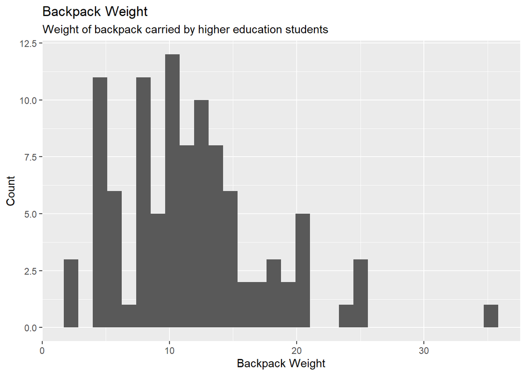

```r
backpack %>%
  ggplot() +
  geom_histogram() +
  aes(
    x = backpack_weight
  ) +
  labs(
    x = "Backpack Weight",
    y = "Count",
    title = "Backpack Weight",
    subtitle = "Weight of backpack carried by higher education students"
  )
```

The above histogram shows that the backpack weight follows an approximately normal distribution with a positive skew.

## 1.3 Question 3

Are there differences in backpack weight between sex?

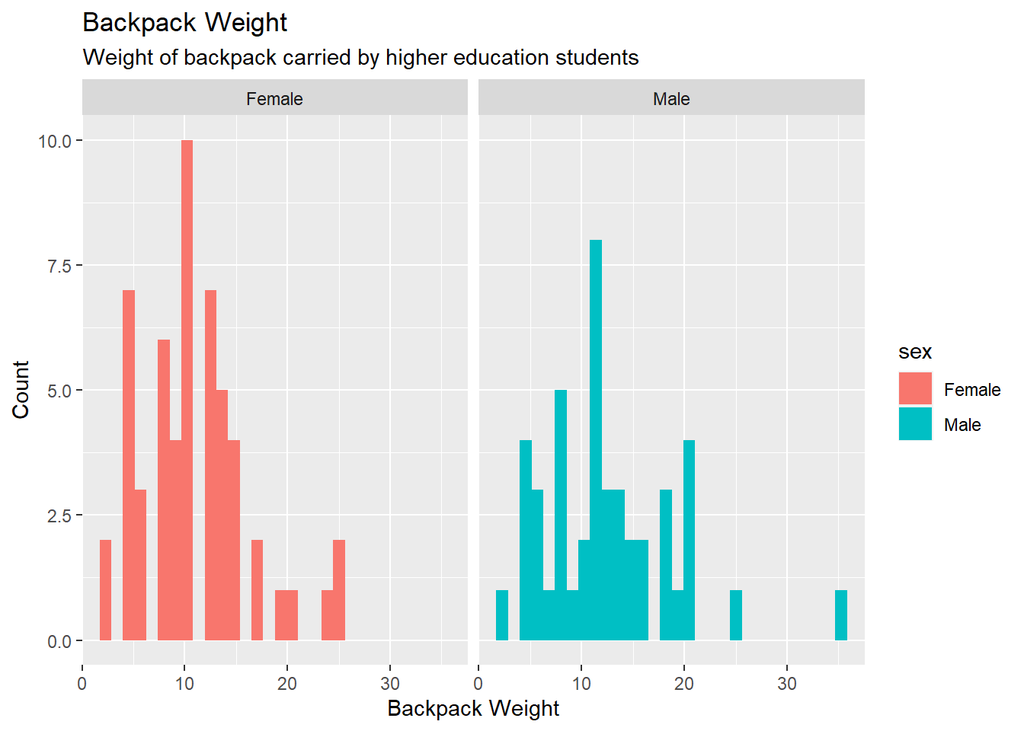

```r
backpack %>%
  ggplot() +
  geom_histogram() +
  aes(
    x = backpack_weight,
    fill = sex
  ) +
  labs(
    x = "Backpack Weight",
    y = "Count",
    title = "Backpack Weight",
    subtitle = "Weight of backpack carried by higher education students"
  ) +
  facet_wrap(
    ~sex
  )
```

Both sexes follow approximately the same distribution, but the data for female students is more clustered around the median value of 11.

## 1.4 Question 4

What is the relationship between body weight and backpack weight?

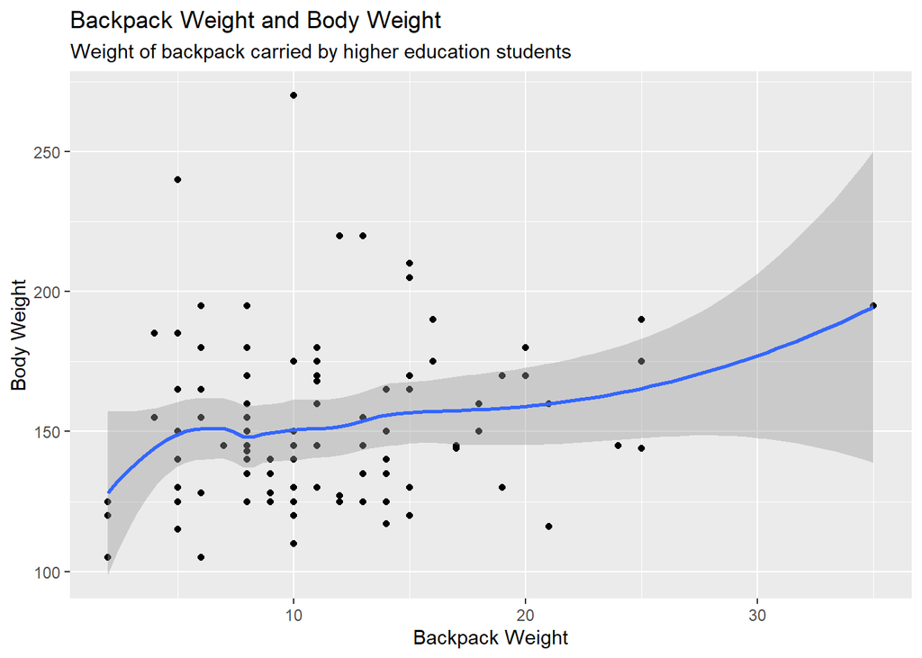

```r
backpack %>%
  ggplot() +
  geom_point() +
  geom_smooth() +
  aes(
    x = backpack_weight,
    y = body_weight
  ) +
  labs(
    x = "Backpack Weight",
    y = "Body Weight",
    title = "Backpack Weight and Body Weight",
    subtitle = "Weight of backpack carried by higher education students"
  )
```

There appears to be no relationship between backpack weight and body weight. There is, at a stretch, a very weak positive correlation.

## 1.5 Question 5

Is this relationship different between men and women? Choose an appropriate plot and interpret your findings.

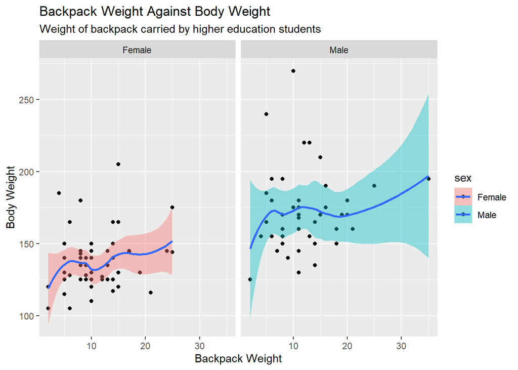

```r
backpack %>%
  ggplot() +
  geom_point() +
  geom_smooth() +
  aes(
    x = backpack_weight,
    y = body_weight,
    fill = sex
  ) +
  labs(
    x = "Backpack Weight",
    y = "Body Weight",
    title = "Backpack Weight Against Body Weight",
    subtitle = "Weight of backpack carried by higher education students"
  ) +
  facet_wrap(
    ~sex
  )
```

The relationship appears to be the same when adjusted for sex, noting that one male student is exaggerating the correlation at the far end of the data.

## 1.6 Question 6

What **proportion** of students report back pain?

```r
sum(backpack$back_problems) / length(backpack$back_problems) * 100
```

```
## [1] 32
```

32% of students report back pain.

## 1.7 Question 7

Is this proportion different between men and women?

```r
backpack_problems_male <- backpack %>%
  filter(
    sex == "Male"
  ) %>%
  select(
    back_problems
  ) %>%
  as_vector() %>%
  as.logical()

backpack_problems_female <- backpack %>%
  filter(
    sex == "Female"
  ) %>%
  select(
    back_problems
  ) %>%
  as_vector() %>%
  as.logical()
```

```r
round(
  sum(backpack_problems_male) / length(backpack_problems_male) * 100,
  2
)
```

```
## [1] 17.78
```

17.78% of male students report back pain.

```r
round(
  sum(backpack_problems_female) / length(backpack_problems_female) * 100,
  2
)
```

```
## [1] 43.64
```

43.64% of female students report back pain. This is a total difference of female students being 25.86% more likely to report back pain.

## 1.8 Question 8

Now you’ve investigated your data separately, create plots to describe the relationship between backpack weight, body weight, gender and reported backpain.

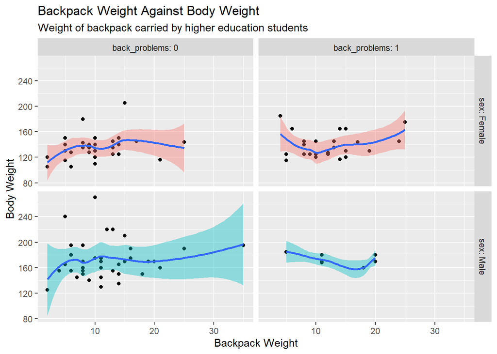

```r
backpack %>%
  ggplot() +
  geom_point() +
  geom_smooth(
    aes(
      fill = sex
    ),
    show.legend = FALSE
  ) +
  aes(
    x = backpack_weight,
    y = body_weight
  ) +
  labs(
    x = "Backpack Weight",
    y = "Body Weight",
    title = "Backpack Weight Against Body Weight",
    subtitle = "Weight of backpack carried by higher education students"
  ) +
  facet_grid(
    ~sex ~back_problems,
    labeller = "label_both"
  )
```

We see that the paucity of male students who have reported back problems has resulted in very few data points in the male with back problems plot.